Group Name - Group 166  
Student Name - Akshat Vijayvargia  
Student ID - s3826627

# PREDICTING CUSTOMER AGE

# INTRODUCTION

This investigation is to predict the Customer Age from Credit Card Customers dataset from Kaggle Repository. On the basis of our analysis, Bank can get to know about future attrition of customers and can figure ways to retain them.

**Data Source -**

The dataset is taken from Kaggle Repository at  
https://www.kaggle.com/sakshigoyal7/credit-card-customers.

Credit Card Customers.(2020).BankChurners [Data File]. Retrieved from  
https://www.kaggle.com/sakshigoyal7/credit-card-customers

## REPORT OVERVIEW

This project of predicting Customer Age has two phases -

**Phase 1 -** In Phase 1, I performed some basic functions of Data Wrangling and some descriptive statistics on the data.  
**Phase 2 -** In Phase 2, we will perform different Machine Learning regression algorithms on the data to predict the customer age.

For this report, we will use the same dataset which we used in Phase 1. Originally, this dataset has 10127 rows and 22 features, out of which we used and will use only 9 features. In Phase 1, we randomly selected only 5000 rows and did some wrangling on the same. But in Phase 2, first, will transform the data by encoding descriptive features and then scaling them. Secondly, we will split 5000 rows into train and test data in most used 80-20 proportion, where 80% of the data is for **train** and 20% of the data is for **test**. As a result, our training data will have 4000 rows and our test data will have 1000 rows.

| SPLIT | NUMBER OF ROWS | PURPOSE |
| --- | --- | --- |
| TRAINING | 4000 ROWS | FITTING ALGORITHMS AND OPTIMIZING HYPER PARAMETERS |
| TESTING | 1000 ROWS | TO COMPARE PERFORMANCES OF DIFFERENT ALGORITHMS |

## OVERVIEW OF METHODOLOGY

The aim of this investigation is to try and evaluate the best model for our continous target feature. To have a brief understanding of what to expect in this report-

**1) Data Preparation** - In this section, we will apply encoding to our categorical descriptive features and then perform scaling on the dataset. It's very important and the very first step of any problem as it makes all the features in float64 datatype.

**2) Selection of Feature** - This section is to identify the best variables in the data. This can be done by using Forrest Importance, F- score or SPSA ( developed by Prof. Vural Aksakalli of RMIT University. However, we used Mutual Information technique to get the best features and their importances.

**3) Model Fitting and Tuning** - In this section, I have used RepeatedKFold and negative mean squared error as a performance metrics. For predicting target feature, I have used following regressors -  
*K-Nearest Neighbour Pipeline  
Parameters used are -  
*'fselector__score_func': [fs.f_regression, fs.mutual_info_regression],*  
*'fselector__k': [2,15,21, DATA.shape[1]],*  
*'knn__n_neighbors': [1, 5, 10],*  
*'knn__p': [1, 2]*

*Decision Tree Pipeline  
Parameters used are -  
*'fselector__k': [2,15,21, DATA.shape[1]],*  
'dtcriterion': ['mse'],  
'dtmax_depth': [1, 2, 3, 4],  
'dt__min_samples_split': [5, 50, 100, 150]*

*Random Forest Pipeline  
Parameters used are-  
*'fselector__k': [2,15,21, DATA.shape[1]],*  
'rfcriterion': ['mse'],  
'rfmax_depth': [1, 2, 3, 4],  
'rf__min_samples_split': [5, 50, 100, 150]*

**4) Model Comparison** - This is the last step, where we compared models by applying Cross Validation on the test set and then performing paired ttest on the cv scores.  
*Models compared based T-test were-*

- KNN vs DT
- KNN vs RF
- RF vs DT

# DATA PREPARATION

As most of the data wrangling process is already done in Phase 1, so we only have to import the dataset, check the datatypes and perform descriptive statistics on numerical and categorical features separately.

```python
# Loading required packages
import pandas as pd
import numpy as np
import io, joblib, math, numpy as np, os, pandas as pd, sklearn, warnings
from scipy import stats
warnings.filterwarnings("ignore")
# all of the sklearn libraries:
from sklearn import feature_selection as fs
from sklearn import preprocessing
from sklearn import preprocessing
from sklearn.ensemble import RandomForestRegressor
from sklearn.feature_selection import SelectKBest
from sklearn.metrics import mean_squared_error
from sklearn.model_selection import cross_val_score
from sklearn.model_selection import GridSearchCV
from sklearn.model_selection import RepeatedKFold
from sklearn.model_selection import train_test_split
from sklearn.neighbors import KNeighborsRegressor
from sklearn.pipeline import Pipeline
import sklearn.metrics as metrics
from sklearn.tree import DecisionTreeRegressor
import matplotlib.pyplot as plt
class color:
   PURPLE = '\033[95m'
   CYAN = '\033[96m'
   DARKCYAN = '\033[36m'
   BLUE = '\033[94m'
   GREEN = '\033[92m'
   YELLOW = '\033[93m'
   RED = '\033[91m'
   BOLD = '\033[1m'
   UNDERLINE = '\033[4m'
   END = '\033[0m'

# Importing the dataset
pd.set_option('display.max_columns',None)
DF=pd.read_csv(r"C:/Users/61422/Desktop/Exported.csv")
```

```python
DF.head()
```

|  | Attrition_Flag | Customer_Age | Gender | Dependent_count | Education_Level | Marital_Status | Income_Category | Card_Category | Avg_Utilization_Ratio |
| --- | --- | --- | --- | --- | --- | --- | --- | --- | --- |
| 0 | Existing Customer | 52 | M | 2 | Uneducated | Single | $80K - $120K | Blue | 0.069 |
| 1 | Existing Customer | 49 | F | 3 | Uneducated | Married | Less than $40K | Blue | 0.370 |
| 2 | Existing Customer | 36 | F | 3 | Graduate | Single | Unknown | Blue | 0.069 |
| 3 | Attrited Customer | 34 | M | 3 | Post-Graduate | Single | $40K - $60K | Blue | 0.000 |
| 4 | Existing Customer | 52 | M | 3 | Graduate | Single | $80K - $120K | Blue | 0.000 |

```python
print(color.BOLD + f"Dimension of the data set is {DF.shape} \n" + color.END)
print(color.BOLD + f"Data types are: " + color.END)
print(DF.dtypes)
```

```
Dimension of the data set is (5000, 9)

Data types are:
Attrition_Flag            object
Customer_Age               int64
Gender                    object
Dependent_count            int64
Education_Level           object
Marital_Status            object
Income_Category           object
Card_Category             object
Avg_Utilization_Ratio    float64
dtype: object
```

```python
print(color.BOLD + 'Summary Statistics Of Numeric Features' + color.END)
DF.describe(include=np.number).round(3)
```

```
Summary Statistics Of Numeric Features
```

|  | Customer_Age | Dependent_count | Avg_Utilization_Ratio |
| --- | --- | --- | --- |
| count | 5000.000 | 5000.000 | 5000.000 |
| mean | 46.236 | 2.355 | 0.275 |
| std | 8.004 | 1.298 | 0.276 |
| min | 26.000 | 0.000 | 0.000 |
| 25% | 41.000 | 1.000 | 0.022 |
| 50% | 46.000 | 2.000 | 0.174 |
| 75% | 52.000 | 3.000 | 0.504 |
| max | 70.000 | 5.000 | 0.994 |

```python
print(color.BOLD + 'Summary Statistics Of Categorical Features' + color.END)
DF.describe(include=np.object).round(3)
```

```
Summary Statistics Of Categorical Features
```

|  | Attrition_Flag | Gender | Education_Level | Marital_Status | Income_Category | Card_Category |
| --- | --- | --- | --- | --- | --- | --- |
| count | 5000 | 5000 | 5000 | 5000 | 5000 | 5000 |
| unique | 2 | 2 | 7 | 4 | 6 | 4 |
| top | Existing Customer | F | Graduate | Married | Less than $40K | Blue |
| freq | 4186 | 2653 | 1551 | 2323 | 1769 | 4657 |

We have already cleaned our dataset in Phase 1. So lets now directly encode our categorical variables.

## ENCODING OF FEATURES

Prior to modelling, all categorical features (both the target feature and the descriptive features) must be encoded into a set of numerical features.

Since, our target feature is continous, we can directly split the dataset into *TARGET* and *DATA*.

```python
# Storing the data in the form of dependent and independent featues separately
TARGET=DF.iloc[:,1]
DATA=DF.drop(columns='Customer_Age')
```

### ENCODING CATEGORICAL DESCRIPTIVE FEATURES

```python
CATG=DATA.columns[DATA.dtypes==object].tolist()
print(color.BOLD + 'Categorical Columns Are-' + color.END)
CATG
```

```
Categorical Columns Are-
```

```
['Attrition_Flag',
 'Gender',
 'Education_Level',
 'Marital_Status',
 'Income_Category',
 'Card_Category']
```

```python
for col in CATG:
    n=len(DATA[col].unique())
    if n==2:
        DATA[col]=pd.get_dummies(DATA[col],drop_first=True)

DATA=pd.get_dummies(DATA)
DATA_COLS=DATA.columns
```

## SCALING OF FEATURES

After encoding, now will scale the dataset using MinMax Scaling.

```python
from sklearn import preprocessing
DATA = pd.DataFrame(preprocessing.MinMaxScaler().fit_transform(DATA),
                    columns=DATA_COLS)
```

```python
DATA.shape
```

```
(5000, 25)
```

```python
DATA.head()
```

|  | Attrition_Flag | Gender | Dependent_count | Avg_Utilization_Ratio | Education_Level_College | Education_Level_Doctorate | Education_Level_Graduate | Education_Level_High School | Education_Level_Post-Graduate | Education_Level_Uneducated | Education_Level_Unknown | Marital_Status_Divorced | Marital_Status_Married | Marital_Status_Single | Marital_Status_Unknown | Income_Category_$120K + | Income_Category_$40K - $60K | Income_Category_$60K - $80K | Income_Category_$80K - $120K | Income_Category_Less than $40K | Income_Category_Unknown | Card_Category_Blue | Card_Category_Gold | Card_Category_Platinum | Card_Category_Silver |
| --- | --- | --- | --- | --- | --- | --- | --- | --- | --- | --- | --- | --- | --- | --- | --- | --- | --- | --- | --- | --- | --- | --- | --- | --- | --- |
| 0 | 1.0 | 1.0 | 0.4 | 0.069416 | 0.0 | 0.0 | 0.0 | 0.0 | 0.0 | 1.0 | 0.0 | 0.0 | 0.0 | 1.0 | 0.0 | 0.0 | 0.0 | 0.0 | 1.0 | 0.0 | 0.0 | 1.0 | 0.0 | 0.0 | 0.0 |
| 1 | 1.0 | 0.0 | 0.6 | 0.372233 | 0.0 | 0.0 | 0.0 | 0.0 | 0.0 | 1.0 | 0.0 | 0.0 | 1.0 | 0.0 | 0.0 | 0.0 | 0.0 | 0.0 | 0.0 | 1.0 | 0.0 | 1.0 | 0.0 | 0.0 | 0.0 |
| 2 | 1.0 | 0.0 | 0.6 | 0.069416 | 0.0 | 0.0 | 1.0 | 0.0 | 0.0 | 0.0 | 0.0 | 0.0 | 0.0 | 1.0 | 0.0 | 0.0 | 0.0 | 0.0 | 0.0 | 0.0 | 1.0 | 1.0 | 0.0 | 0.0 | 0.0 |
| 3 | 0.0 | 1.0 | 0.6 | 0.000000 | 0.0 | 0.0 | 0.0 | 0.0 | 1.0 | 0.0 | 0.0 | 0.0 | 0.0 | 1.0 | 0.0 | 0.0 | 1.0 | 0.0 | 0.0 | 0.0 | 0.0 | 1.0 | 0.0 | 0.0 | 0.0 |
| 4 | 1.0 | 1.0 | 0.6 | 0.000000 | 0.0 | 0.0 | 1.0 | 0.0 | 0.0 | 0.0 | 0.0 | 0.0 | 0.0 | 1.0 | 0.0 | 0.0 | 0.0 | 0.0 | 1.0 | 0.0 | 0.0 | 1.0 | 0.0 | 0.0 | 0.0 |

```python
DATA.info()
```

```
<class 'pandas.core.frame.DataFrame'>
RangeIndex: 5000 entries, 0 to 4999
Data columns (total 25 columns):
 #   Column                          Non-Null Count  Dtype
---  ------                          --------------  -----
 0   Attrition_Flag                  5000 non-null   float64
 1   Gender                          5000 non-null   float64
 2   Dependent_count                 5000 non-null   float64
 3   Avg_Utilization_Ratio           5000 non-null   float64
 4   Education_Level_College         5000 non-null   float64
 5   Education_Level_Doctorate       5000 non-null   float64
 6   Education_Level_Graduate        5000 non-null   float64
 7   Education_Level_High School     5000 non-null   float64
 8   Education_Level_Post-Graduate   5000 non-null   float64
 9   Education_Level_Uneducated      5000 non-null   float64
```

[output cut: 17 more lines]

```python
TARGET.shape
```

```
(5000,)
```

```python
TARGET.head()
```

```
0    52
1    49
2    36
3    34
4    52
Name: Customer_Age, dtype: int64
```

# PREDICTIVE MODELING

## FEATURE SELECTION

In this part, we will try to have a look at the top 5 most important features of our data. Here, we will use Mutual information to find the best features and their importances.

```python
from sklearn import feature_selection as fs
NUM_FEATURES=5

MUTUAL_INFO_FIT = fs.SelectKBest(fs.mutual_info_regression, k=NUM_FEATURES)
MUTUAL_INFO_FIT.fit_transform(DATA,TARGET)
MUTUAL_INFO_INDICES = np.argsort(MUTUAL_INFO_FIT.scores_)[::-1][0:NUM_FEATURES]
BEST_FEATURE = DATA.columns[MUTUAL_INFO_INDICES].values
print(color.BOLD + f"Most important features are {BEST_FEATURE} \n" + color.END)
```

```
Most important features are ['Dependent_count' 'Card_Category_Silver' 'Income_Category_$80K - $120K'
 'Marital_Status_Unknown' 'Avg_Utilization_Ratio']
```

```python
FEATURE_IMPORTANCE = MUTUAL_INFO_FIT.scores_[MUTUAL_INFO_INDICES]
print(color.BOLD + f"Importance of above features are {FEATURE_IMPORTANCE} \n" + color.END)
```

```
Importance of above features are [0.21831451 0.01249187 0.01111995 0.00914629 0.00655043]
```

| Name Of Features | Feature Importance |
| --- | --- |
| Dependent_count | 0.21831451 |
| Card_Category_Silver | 0.01249187 |
| Income*Category*$80K - $120K | 0.01111995 |
| Marital_Status_Unknown | 0.00914629 |
| Avg_Utilization_Ratio | 0.00655043 |

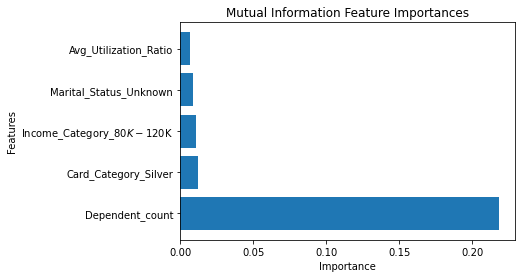

```python
def plot_imp(best_features, scores, method_name):
    plt.barh(best_features, scores)
    plt.title(method_name + ' Feature Importances')
    plt.xlabel("Importance")
    plt.ylabel("Features")
    plt.show()

plot_imp(BEST_FEATURE, FEATURE_IMPORTANCE, 'Mutual Information')
```

From the above graph, we can observe that the *most important feature is **Dependent_Count** followed by **Card_Category_Silver** and **Income_Category_80k-120k**.*

### TRAIN-TEST SPLITTING

Our dataset has 5000 rows, so we will split the data in 80-20 proportion. 80% for the training set, which makes 4000 rows and 20% for the test set, which makes it 1000 rows.

```python
from sklearn.model_selection import train_test_split
DATA_TRAIN,DATA_TEST,TARGET_TRAIN,TARGET_TEST=train_test_split(DATA,TARGET,test_size=0.2,random_state=999)

print(color.BOLD + f"The shape of Data Training Set {DATA_TRAIN.shape} \n" + color.END)
print(color.BOLD + f"The shape of Target Training Set {TARGET_TRAIN.shape} \n" + color.END)
print(color.BOLD + f"The shape of Data Testing Set {DATA_TEST.shape} \n" + color.END)
print(color.BOLD + f"The shape of Target Testing Set {TARGET_TEST.shape} \n" + color.END)
```

```
The shape of Data Training Set (4000, 25)

The shape of Target Training Set (4000,)

The shape of Data Testing Set (1000, 25)

The shape of Target Testing Set (1000,)
```

### MODEL EVALUATION STRATEGY

```python
from sklearn.model_selection import RepeatedKFold, GridSearchCV
cv_method = RepeatedKFold(n_splits=5, random_state=999)
```

## MODEL FITTING AND TUNING

### K-NEAREST NEIGHBOR PIPELINE

```python
from sklearn.neighbors import KNeighborsRegressor

cv_method = RepeatedKFold(n_splits=3, random_state=999)

PIPE_KNN = Pipeline([('fselector', SelectKBest()),
                     ('knn', KNeighborsRegressor())])

PARAM_PIPE_KNN = {'fselector__score_func': [fs.f_regression, fs.mutual_info_regression],
                   'fselector__k': [2,15,21, DATA.shape[1]],
                   'knn__n_neighbors': [1, 5, 10],
                   'knn__p': [1, 2]}

GRID_PIPE_KNN = GridSearchCV(estimator=PIPE_KNN,
                           param_grid=PARAM_PIPE_KNN,
                           cv=cv_method,
                           n_jobs=-2,
                           scoring='neg_mean_squared_error',
                           verbose=1)
```

```python
GRID_PIPE_KNN.fit(DATA_TRAIN,TARGET_TRAIN);
```

```
Fitting 30 folds for each of 48 candidates, totalling 1440 fits
```

```
[Parallel(n_jobs=-2)]: Using backend LokyBackend with 7 concurrent workers.
[Parallel(n_jobs=-2)]: Done  36 tasks      | elapsed:    3.7s
[Parallel(n_jobs=-2)]: Done 326 tasks      | elapsed:  1.1min
[Parallel(n_jobs=-2)]: Done 576 tasks      | elapsed:  1.7min
[Parallel(n_jobs=-2)]: Done 926 tasks      | elapsed:  3.6min
[Parallel(n_jobs=-2)]: Done 1376 tasks      | elapsed:  6.3min
[Parallel(n_jobs=-2)]: Done 1440 out of 1440 | elapsed:  6.9min finished
```

```python
GRID_PIPE_KNN.best_params_
```

```
{'fselector__k': 15,
 'fselector__score_func': <function sklearn.feature_selection._univariate_selection.f_regression(X, y, *, center=True)>,
 'knn__n_neighbors': 10,
 'knn__p': 2}
```

```python
GRID_PIPE_KNN.best_estimator_
```

```
Pipeline(steps=[('fselector',
                 SelectKBest(k=15,
                             score_func=<function f_regression at 0x0000025AE0C908B0>)),
                ('knn', KNeighborsRegressor(n_neighbors=10))])
```

```python
print(color.BOLD + f"Negative MSE of KNN is {GRID_PIPE_KNN.best_score_} \n" + color.END)
print(color.BOLD + "The best performing KNN selected 15 features with 10 nearest neighbors and p as 2, which is Euclidean distance." + color.END)
```

```
Negative MSE of KNN is -66.81639676710783

The best performing KNN selected 15 features with 10 nearest neighbors and p as 2, which is Euclidean distance.
```

```python
def get_search_results(gs):

    def model_result(scores, params):
        scores = {'mean_score': np.mean(scores),
             'std_score': np.std(scores),
             'min_score': np.min(scores),
             'max_score': np.max(scores)}
        return pd.Series({**params,**scores})

    models = []
    scores = []

    for i in range(gs.n_splits_):
        key = f"split{i}_test_score"
        r = gs.cv_results_[key]
        scores.append(r.reshape(-1,1))

    all_scores = np.hstack(scores)
    for p, s in zip(gs.cv_results_['params'], all_scores):
        models.append((model_result(s, p)))

    pipe_results = pd.concat(models, axis=1).T.sort_values(['mean_score'], ascending=False)

    columns_first = ['mean_score', 'std_score', 'max_score', 'min_score']
    columns = columns_first + [c for c in pipe_results.columns if c not in columns_first]

    return pipe_results[columns]
```

```python
RESULT_KNN = get_search_results(GRID_PIPE_KNN)
RESULT_KNN.head()
```

|  | mean_score | std_score | max_score | min_score | fselector__k | fselector__score_func | knn__n_neighbors | knn__p |
| --- | --- | --- | --- | --- | --- | --- | --- | --- |
| 17 | -66.8164 | 2.59672 | -62.2312 | -73.1006 | 15 | <function f_regression at 0x0000025AE0C908B0> | 10 | 2 |
| 16 | -66.9192 | 2.70784 | -62.2456 | -73.2168 | 15 | <function f_regression at 0x0000025AE0C908B0> | 10 | 1 |
| 23 | -67.1312 | 2.68832 | -63.3464 | -72.8181 | 15 | <function mutual_info_regression at 0x0000025A... | 10 | 2 |
| 34 | -67.1439 | 2.62268 | -61.5682 | -72.5437 | 21 | <function mutual_info_regression at 0x0000025A... | 10 | 1 |
| 35 | -67.2228 | 2.51839 | -62.0376 | -73.3773 | 21 | <function mutual_info_regression at 0x0000025A... | 10 | 2 |

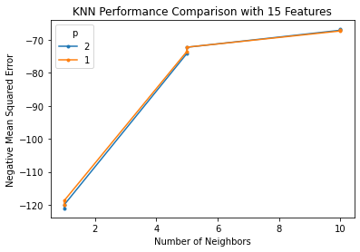

```python
results_KNN_15_features = RESULT_KNN[RESULT_KNN['fselector__k'] == 15.0]

for i in results_KNN_15_features['knn__p'].unique():
    temp = results_KNN_15_features[results_KNN_15_features['knn__p'] == i]
    plt.plot(temp['knn__n_neighbors'], temp['mean_score'], marker = '.', label = i)

plt.legend(title = "p")
plt.xlabel('Number of Neighbors')
plt.ylabel("Negative Mean Squared Error")
plt.title("KNN Performance Comparison with 15 Features")
plt.show()
```

### DECISION TREE PIPELINE

```python
from sklearn.tree import DecisionTreeRegressor

df_regressor = DecisionTreeRegressor(random_state=999)

PARAM_PIPE_DT = {'fselector__k': [2,15,21, DATA.shape[1]],
                  'dt__criterion': ['mse'],
                  'dt__max_depth': [1, 2, 3, 4],
                  'dt__min_samples_split': [5, 50, 100, 150]}

PIPE_DT = Pipeline([(
    'fselector',
    SelectKBest(score_func=fs.f_regression)),
    ('dt', df_regressor)])

GRID_PIPE_DT = GridSearchCV(
    PIPE_DT,
    PARAM_PIPE_DT,
    cv=cv_method,
    n_jobs=-2,
    scoring='neg_mean_squared_error',
    refit='neg_mean_squared_error',
    verbose=1
)
```

```python
GRID_PIPE_DT.fit(DATA_TRAIN,TARGET_TRAIN);
```

```
Fitting 30 folds for each of 64 candidates, totalling 1920 fits
```

```
[Parallel(n_jobs=-2)]: Using backend LokyBackend with 7 concurrent workers.
[Parallel(n_jobs=-2)]: Done  74 tasks      | elapsed:    0.3s
[Parallel(n_jobs=-2)]: Done 1250 tasks      | elapsed:    3.7s
[Parallel(n_jobs=-2)]: Done 1920 out of 1920 | elapsed:    5.6s finished
```

```python
GRID_PIPE_DT.best_params_
```

```
{'dt__criterion': 'mse',
 'dt__max_depth': 1,
 'dt__min_samples_split': 5,
 'fselector__k': 2}
```

```python
GRID_PIPE_DT.best_estimator_
```

```
Pipeline(steps=[('fselector',
                 SelectKBest(k=2,
                             score_func=<function f_regression at 0x0000025AE0C908B0>)),
                ('dt',
                 DecisionTreeRegressor(max_depth=1, min_samples_split=5,
                                       random_state=999))])
```

```python
print(color.BOLD + f"Negative MSE of DT is {GRID_PIPE_DT.best_score_} \n" + color.END)
print(color.BOLD + "The optimal value of maximum depth hyperparameter is at 1 with minimum sample split of 5 and selected 2 features." + color.END)
```

```
Negative MSE of DT is -62.295032688621184

The optimal value of maximum depth hyperparameter is at 1 with minimum sample split of 5 and selected 2 features.
```

```python
results_DT = get_search_results(GRID_PIPE_DT)
results_DT.head()
```

|  | mean_score | std_score | max_score | min_score | dt__criterion | dt__max_depth | dt__min_samples_split | fselector__k |
| --- | --- | --- | --- | --- | --- | --- | --- | --- |
| 0 | -62.295 | 2.75018 | -57.0065 | -68.4559 | mse | 1 | 5 | 2 |
| 9 | -62.295 | 2.75018 | -57.0065 | -68.4559 | mse | 1 | 100 | 15 |
| 1 | -62.295 | 2.75018 | -57.0065 | -68.4559 | mse | 1 | 5 | 15 |
| 15 | -62.295 | 2.75018 | -57.0065 | -68.4559 | mse | 1 | 150 | 25 |
| 14 | -62.295 | 2.75018 | -57.0065 | -68.4559 | mse | 1 | 150 | 21 |

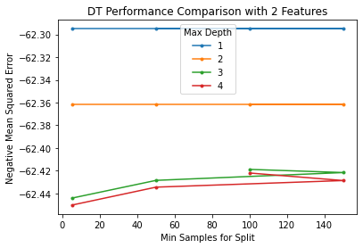

```python
results_DT_2_features = results_DT[results_DT['fselector__k'] == 2.0]
results_DT_2_features.head()

for i in results_DT_2_features['dt__max_depth'].unique():
    temp = results_DT_2_features[results_DT_2_features['dt__max_depth'] == i]
    plt.plot(temp['dt__min_samples_split'], temp['mean_score'], marker = '.', label = i)

plt.legend(title = "Max Depth")
plt.xlabel('Min Samples for Split')
plt.ylabel("Negative Mean Squared Error")
plt.title("DT Performance Comparison with 2 Features")
plt.show()
```

### RANDOM FOREST PIPELINE

```python
from sklearn.ensemble import RandomForestRegressor

rf_regressor=RandomForestRegressor(random_state=999)

PARAM_PIPE_RF = {'fselector__k': [2,15,21, DATA.shape[1]],
                  'rf__criterion': ['mse'],
                  'rf__max_depth': [1, 2, 3, 4],
                  'rf__min_samples_split': [5, 50, 100, 150],
                  }

PIPE_RF = Pipeline([(
    'fselector',
    SelectKBest(score_func=fs.f_regression)),
    ('rf', rf_regressor)])

GRID_PIPE_RF = GridSearchCV(PIPE_RF,
                            PARAM_PIPE_RF,
                            cv=cv_method,
                            n_jobs=-2,
                            scoring='neg_mean_squared_error',
                            refit='neg_mean_squared_error',
                            verbose=1
                           )
```

```python
GRID_PIPE_RF.fit(DATA_TRAIN,TARGET_TRAIN);
```

```
Fitting 30 folds for each of 64 candidates, totalling 1920 fits
```

```
[Parallel(n_jobs=-2)]: Using backend LokyBackend with 7 concurrent workers.
[Parallel(n_jobs=-2)]: Done  36 tasks      | elapsed:    1.5s
[Parallel(n_jobs=-2)]: Done 186 tasks      | elapsed:    7.3s
[Parallel(n_jobs=-2)]: Done 436 tasks      | elapsed:   17.4s
[Parallel(n_jobs=-2)]: Done 786 tasks      | elapsed:   35.9s
[Parallel(n_jobs=-2)]: Done 1236 tasks      | elapsed:  1.2min
[Parallel(n_jobs=-2)]: Done 1786 tasks      | elapsed:  2.0min
[Parallel(n_jobs=-2)]: Done 1920 out of 1920 | elapsed:  2.3min finished
```

```python
GRID_PIPE_RF.best_params_
```

```
{'fselector__k': 15,
 'rf__criterion': 'mse',
 'rf__max_depth': 2,
 'rf__min_samples_split': 150}
```

```python
GRID_PIPE_RF.best_estimator_
```

```
Pipeline(steps=[('fselector',
                 SelectKBest(k=15,
                             score_func=<function f_regression at 0x0000025AE0C908B0>)),
                ('rf',
                 RandomForestRegressor(max_depth=2, min_samples_split=150,
                                       random_state=999))])
```

```python
print(color.BOLD + f"Negative MSE of RF is {GRID_PIPE_RF.best_score_} \n" + color.END)
print(color.BOLD + "The optimal value of maximum depth hyperparameter is at 2 with minimum sample split of 150 and selected 15 features." + color.END)
```

```
Negative MSE of RF is -62.16697560919192

The optimal value of maximum depth hyperparameter is at 2 with minimum sample split of 150 and selected 15 features.
```

```python
results_RF = pd.DataFrame(GRID_PIPE_RF.cv_results_['params'])
results_RF['test_score'] = GRID_PIPE_RF.cv_results_['mean_test_score']
results_RF.columns
```

```
Index(['fselector__k', 'rf__criterion', 'rf__max_depth',
       'rf__min_samples_split', 'test_score'],
      dtype='object')
```

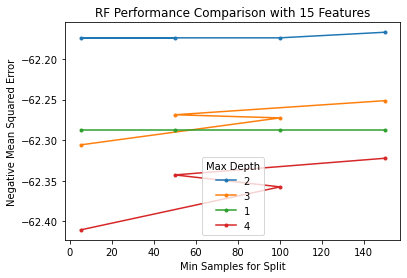

```python
results_RF = get_search_results(GRID_PIPE_RF)
results_RF_15_features = results_RF[results_RF['fselector__k'] == 15.0]

for i in results_RF_15_features['rf__max_depth'].unique():
    temp = results_RF_15_features[results_RF_15_features['rf__max_depth'] == i]
    plt.plot(temp['rf__min_samples_split'], temp['mean_score'], marker = '.', label = i)

plt.legend(title = "Max Depth")
plt.xlabel('Min Samples for Split')
plt.ylabel("Negative Mean Squared Error")
plt.title("RF Performance Comparison with 15 Features")
plt.show()
```

## Model Comparison

For all the three algorithms, we have used 4000 rows training set within our cv framework. After tuning all models, now we will fit the above models with 1000 rows testing set and will perform ttest on the negtive mean squared error.

```python
from sklearn.model_selection import cross_val_score

cv_method_ttest = RepeatedKFold(n_splits=10, random_state=1)

cv_results_KNN = cross_val_score(estimator=GRID_PIPE_KNN.best_estimator_,
                                 X = DATA_TEST,
                                 y = TARGET_TEST,
                                 cv = cv_method_ttest,
                                 n_jobs=-2,
                                 scoring = 'neg_mean_squared_error')
cv_results_KNN.mean()
```

```
-72.50791
```

```python
cv_results_DT = cross_val_score(estimator=GRID_PIPE_DT.best_estimator_,
                                X = DATA_TEST,
                                y = TARGET_TEST,
                                cv = cv_method_ttest,
                                n_jobs = -2,
                                scoring = 'neg_mean_squared_error')
cv_results_DT.mean()
```

```
-65.92005015848835
```

```python
cv_results_RF = cross_val_score(estimator=GRID_PIPE_RF.best_estimator_,
                                X = DATA_TEST,
                                y = TARGET_TEST,
                                cv = cv_method_ttest,
                                n_jobs = -2,
                                scoring = 'neg_mean_squared_error')
cv_results_RF.mean()
```

```
-66.45345779134267
```

Higher MSE indicates the degree of error in a model and the ideal model is alwways with less MSE value.

```python
from scipy import stats

# RF seems to be the best, so let's compare that to the others
# any p-value < 0.05 indicates a statistically significant result

print(stats.ttest_rel(cv_results_KNN, cv_results_DT))
print(stats.ttest_rel(cv_results_KNN, cv_results_RF))
print(stats.ttest_rel(cv_results_RF, cv_results_DT))
```

```
Ttest_relResult(statistic=-13.686032780470658, pvalue=1.4576154544372918e-24)
Ttest_relResult(statistic=-13.044272717522368, pvalue=3.155836161136585e-23)
Ttest_relResult(statistic=-6.206225850287992, pvalue=1.2711711300989644e-08)
```

```python
print(stats.ttest_rel(cv_results_KNN, cv_results_DT))
```

```
Ttest_relResult(statistic=-13.686032780470658, pvalue=1.4576154544372918e-24)
```

# CRITIQUE AND LIMITATIONS

However, to have the proper understanding it would be great, if we could study more on the algorithms and could get some flexibility to not get restricted to only some predictor variables to predict the Customer_Age, but to evaluate and predict near actual numbers, we would need some information about competitors, customer preferences etc. Therefore, this investigation might not be fully true.

The only strength of the investigation is that the dataset is picked from Kaggle Repository, so it can be considered pure and authentic.

# SUMMARY AND CONCLUSIONS

## SUMMARY OF FINDINGS

In the Hyperparameter Tuning and Fitting, we came to know that negative mean squared error of K-Nearest Neighbour is -66.81639676710783 and best performing KNN selected 15 features with 10 nearest neighbors and p as 2, which is Euclidean distance. Secondly, from the ouput of Decision Tree, we came to know that negative mean squared error of Decision Tree is -62.295032688621184 and the optimal value of maximum depth hyperparameter is at 1 with minimum sample split of 5 and selected 2 feature. Moreover, if we look at the results of Random Forrest, we come to know that negative mean squared error of Random Forrest is -62.16697560919192 and optimal value of maximum depth hyperparameter is at 2 with minimum sample split of 150 and selected 15 features.

## CONCLUSIONS

If I could extend my study on this problem, I would make age bracket categories to get to know more about that particular age group, who attrite the bank services.

# REFERENCES

1) FeatureRanking website. Available at - https://www.featureranking.com/. [Accessed 2021-5-24]  
2) RMIT Study Materials. Available at- https://rmit.instructure.com/courses/79988/files/16633051?module_item_id=3006593. [Accessed 2021-5-21]  
3) Dataset website. Kaggle Repository. Available at - https://www.kaggle.com/sakshigoyal7/credit-card-customers. [Accessed 2021-4-8]  
4) Machine Learning Metrics. Available at- https://scikit-learn.org/stable/index.html . [Accessed 2021-4-24]